# Practical Data Science: Analyzing Stock Market Data with R

*More Insight from Multiple Moving Averages*

In this lecture we’ll look at: * Slowing down the moving averages * Adding extra rules

Let’s get some data and load needed libraries:

```r
library(quantmod)
getSymbols(c('EWP', 'SPY'), src='google')

library(TTR)
library(binhf)
```

Let’s recap where we left off in the previous lecture:

```r
EWP.EMA.10 <- EMA(EWP$EWP.Close, n=10, )
EWP.EMA.50 <- EMA(EWP$EWP.Close, n=50, )
EWP.EMA.200 <- EMA(EWP$EWP.Close, n=200, )
Fast.Diff <- EWP.EMA.10 - EWP.EMA.50
Slow.Diff <- EWP.EMA.50 - EWP.EMA.200

# look for long entries
Long_Trades <- ifelse(
Slow.Diff  > 0 &
Fast.Diff  > 0 &
shift(v=as.numeric(Fast.Diff), places=1, dir="right") < 0, EWP$EWP.Close, NA)

# look for long exits (same thing but inverse signts)
Short_Trades <- ifelse(
Slow.Diff  < 0 &
Fast.Diff  < 0 &
shift(v=as.numeric(Fast.Diff), places=1, dir="right") > 0, EWP$EWP.Close, NA)
```

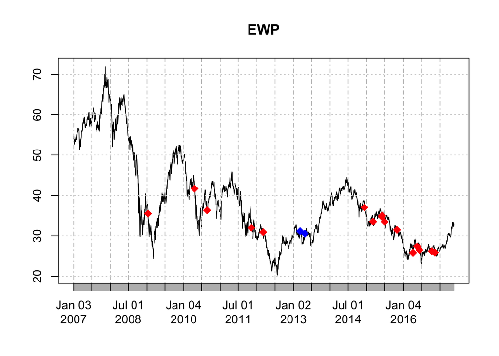

```r
plot(EWP)
points(Long_Trades, col='blue', cex=1.5, pch=18)
points(Short_Trades, col='red', cex=1.5, pch=18)
```

```r
EMA.Fast <- EMA(SPY$SPY.Close, n=10, )
EMA.Medium <- EMA(SPY$SPY.Close, n=50, )
EMA.Slow <- EMA(SPY$SPY.Close, n=200, )
Fast.Diff <- EMA.Fast - EMA.Medium
Slow.Diff <- EMA.Medium - EMA.Slow

# look for long entries
Long_Trades <- ifelse(
Slow.Diff  > 0 &
Fast.Diff  > 0 &
shift(v=as.numeric(Fast.Diff), places=1, dir="right") < 0, SPY$SPY.Close, NA)

# look for long exits (same thing but inverse signts)
Short_Trades <- ifelse(
Slow.Diff  < 0 &
Fast.Diff  < 0 &
shift(v=as.numeric(Fast.Diff), places=1, dir="right") > 0, SPY$SPY.Close, NA)
```

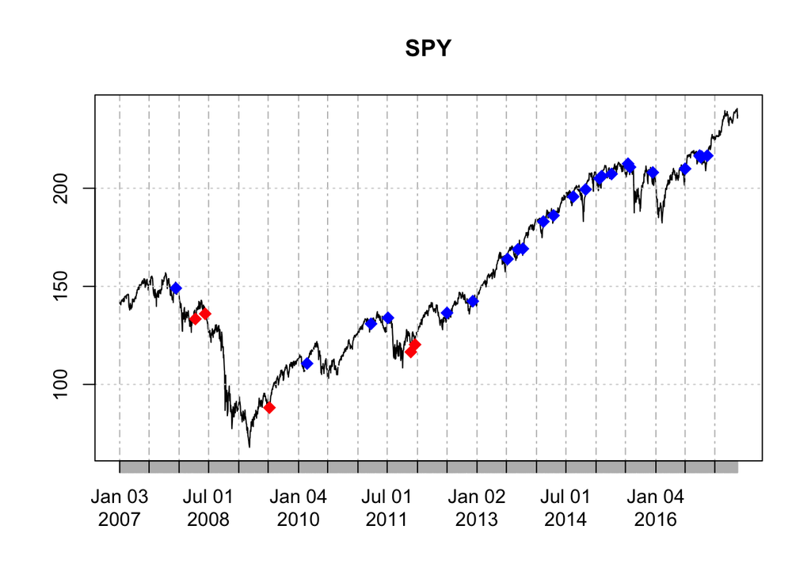

```r
plot(SPY)
points(Long_Trades, col='blue', cex=1.5, pch=18)
points(Short_Trades, col='red', cex=1.5, pch=18)
```

**Slowing down the moving averages**

Let’s see how trying different moving-average periods affect the entry system. Instead of the 10,50,200 series, let’s try both indexes on 20, 100, 300 on the **S&P 500**:

```r
EMA.Fast <- EMA(SPY$SPY.Close, n=20, )
EMA.Medium <- EMA(SPY$SPY.Close, n=100, )
EMA.Slow <- EMA(SPY$SPY.Close, n=300, )
Fast.Diff <- EMA.Fast - EMA.Medium
Slow.Diff <- EMA.Medium - EMA.Slow

# look for long entries
Long_Trades <- ifelse(
        Slow.Diff  > 0 &
                Fast.Diff  > 0 &
                shift(v=as.numeric(Fast.Diff), places=1, dir="right") < 0, SPY$SPY.Close, NA)

# look for long exits (same thing but inverse signts)
Short_Trades <- ifelse(
        Slow.Diff  < 0 &
                Fast.Diff  < 0 &
                shift(v=as.numeric(Fast.Diff), places=1, dir="right") > 0, SPY$SPY.Close, NA)
```

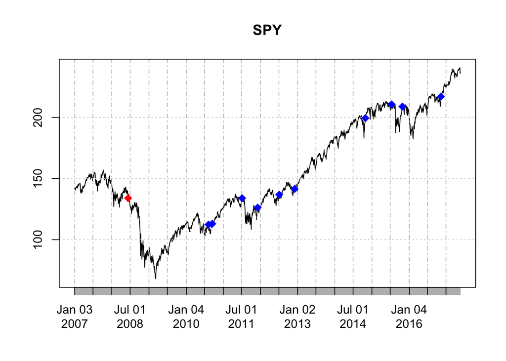

```r
plot(SPY)
points(Long_Trades, col='blue', cex=1.5, pch=18)
points(Short_Trades, col='red', cex=1.5, pch=18)
```

On the **EWP**:

```r
EMA.Fast <- EMA(EWP$EWP.Close, n=20, )
EMA.Medium <- EMA(EWP$EWP.Close, n=100, )
EMA.Slow <- EMA(EWP$EWP.Close, n=300, )
Fast.Diff <- EMA.Fast - EMA.Medium
Slow.Diff <- EMA.Medium - EMA.Slow

# look for long entries
Long_Trades <- ifelse(
        Slow.Diff  > 0 &
                Fast.Diff  > 0 &
                shift(v=as.numeric(Fast.Diff), places=1, dir="right") < 0, EWP$EWP.Close, NA)

# look for long exits (same thing but inverse signts)
Short_Trades <- ifelse(
        Slow.Diff  < 0 &
                Fast.Diff  < 0 &
                shift(v=as.numeric(Fast.Diff), places=1, dir="right") > 0, EWP$EWP.Close, NA)
```

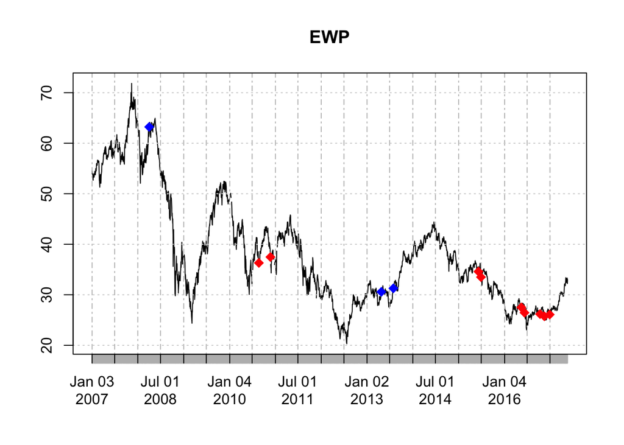

```r
plot(EWP)
points(Long_Trades, col='blue', cex=1.5, pch=18)
points(Short_Trades, col='red', cex=1.5, pch=18)
```

**Adding extra rules**

Let’ try adding an interesting rule twist. Instead of entering when the slower indicator (red colored difference of the slower moving averages) is either above zero for longs and below zero for shorts, let’s enter when its moving in the trade’s direction.

New rules are:

```
    if no position: red-1 < red and blue-1 < 0 and blue > 0 go long
    if long: blue < 0 exit long

    if no position: red-1 > red and blue-1 > 0 and blue < 0 go short
    if short: blue > 0 exit short
```

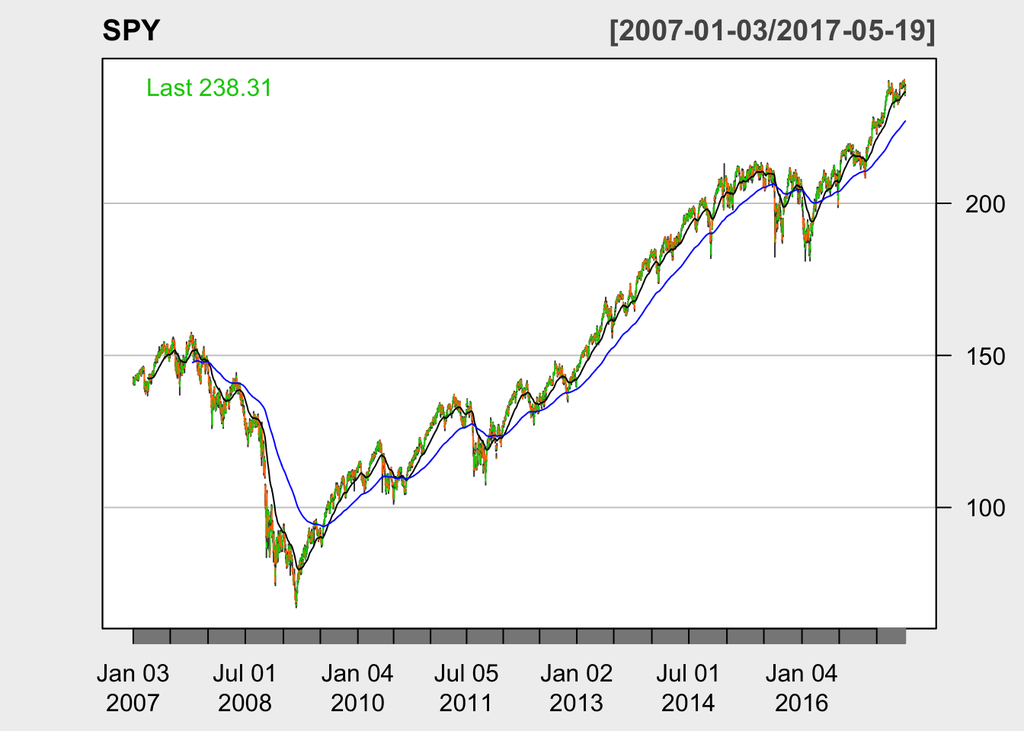

```r
chartSeries(SPY, theme="white", TA="addEMA(50, col='black');addEMA(200, col='blue')")
```

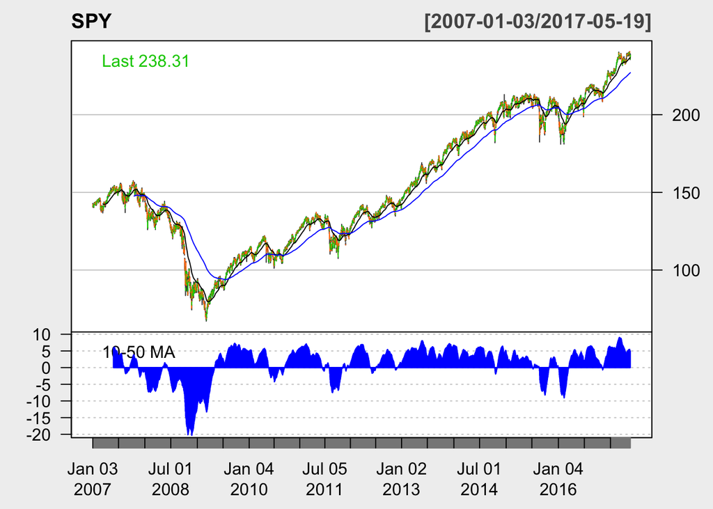

```r
SPY.EMA.10 <- EMA(SPY$SPY.Close, n=20, )
SPY.EMA.50 <- EMA(SPY$SPY.Close, n=100, )
SPY.EMA.200 <- EMA(SPY$SPY.Close, n=300, )
Fast.Diff <- SPY.EMA.10 - SPY.EMA.50
Slow.Diff <- SPY.EMA.50 - SPY.EMA.200
addTA(Fast.Diff, col='blue', type='h',legend="10-50 MA")
```

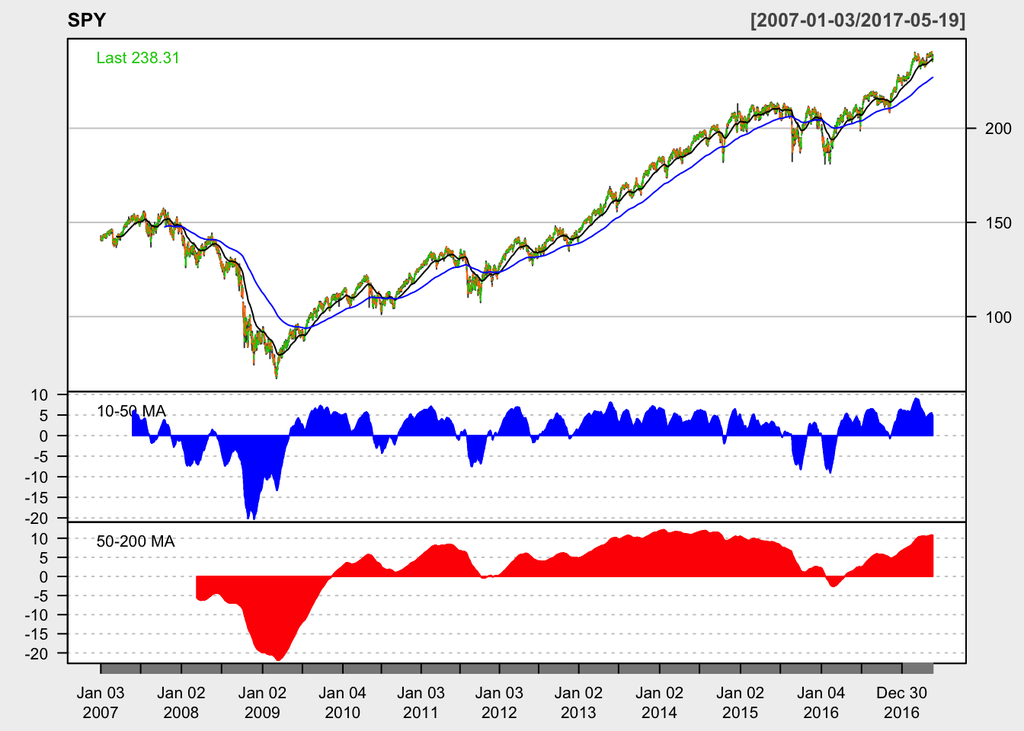

```r
addTA(Slow.Diff, col='red', type='h',legend="50-200 MA")
```

```r
EMA.Fast <- EMA(SPY$SPY.Close, n=20, )
EMA.Medium <- EMA(SPY$SPY.Close, n=100, )
EMA.Slow <- EMA(SPY$SPY.Close, n=300, )
Fast.Diff <- EMA.Fast - EMA.Medium
Slow.Diff <- EMA.Medium - EMA.Slow

# look for trades
Long_Trades <- ifelse(
shift(v=as.numeric(Slow.Diff), places=1, dir="right") < Slow.Diff &
Fast.Diff  > 0 &
shift(v=as.numeric(Fast.Diff), places=1, dir="right") < 0, SPY$SPY.Close, NA)

Short_Trades <- ifelse(
shift(v=as.numeric(Slow.Diff), places=1, dir="right") > Slow.Diff &
Fast.Diff  < 0 &
shift(v=as.numeric(Fast.Diff), places=1, dir="right") > 0, SPY$SPY.Close, NA)
```

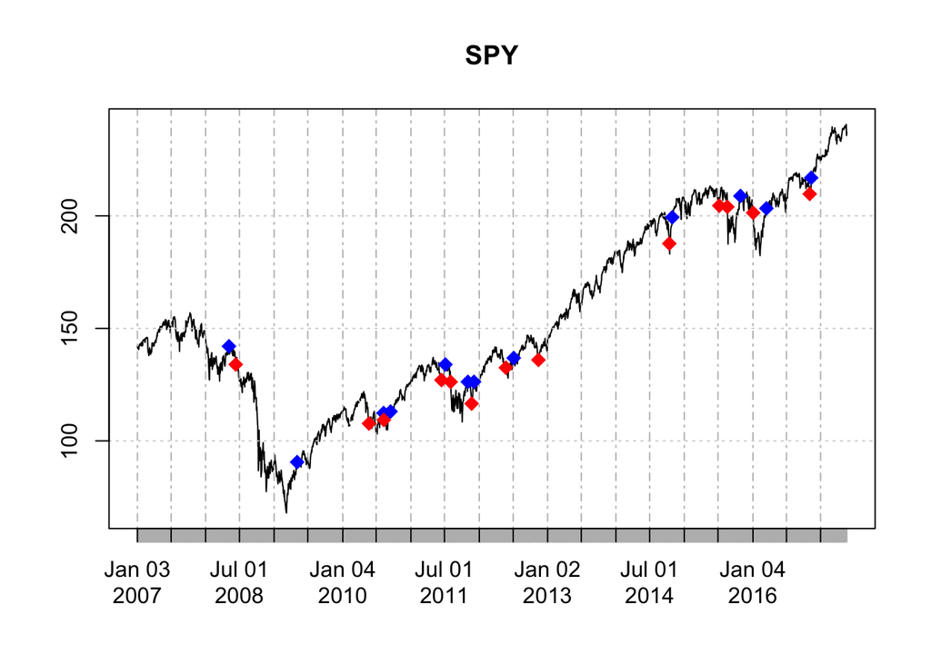

```r
plot(SPY)
points(Long_Trades, col='blue', cex=1.5, pch=18)
points(Short_Trades, col='red', cex=1.5, pch=18)
```

And for **EWP**:

```r
EMA.Fast <- EMA(EWP$EWP.Close, n=20, )
EMA.Medium <- EMA(EWP$EWP.Close, n=100, )
EMA.Slow <- EMA(EWP$EWP.Close, n=300, )
Fast.Diff <- EMA.Fast - EMA.Medium
Slow.Diff <- EMA.Medium - EMA.Slow

# look for trades
Long_Trades <- ifelse(
shift(v=as.numeric(Slow.Diff), places=1, dir="right") < Slow.Diff &
Fast.Diff  > 0 &
shift(v=as.numeric(Fast.Diff), places=1, dir="right") < 0, EWP$EWP.Close, NA)

Short_Trades <- ifelse(
shift(v=as.numeric(Slow.Diff), places=1, dir="right") > Slow.Diff &
Fast.Diff  < 0 &
shift(v=as.numeric(Fast.Diff), places=1, dir="right") > 0, EWP$EWP.Close, NA)
```

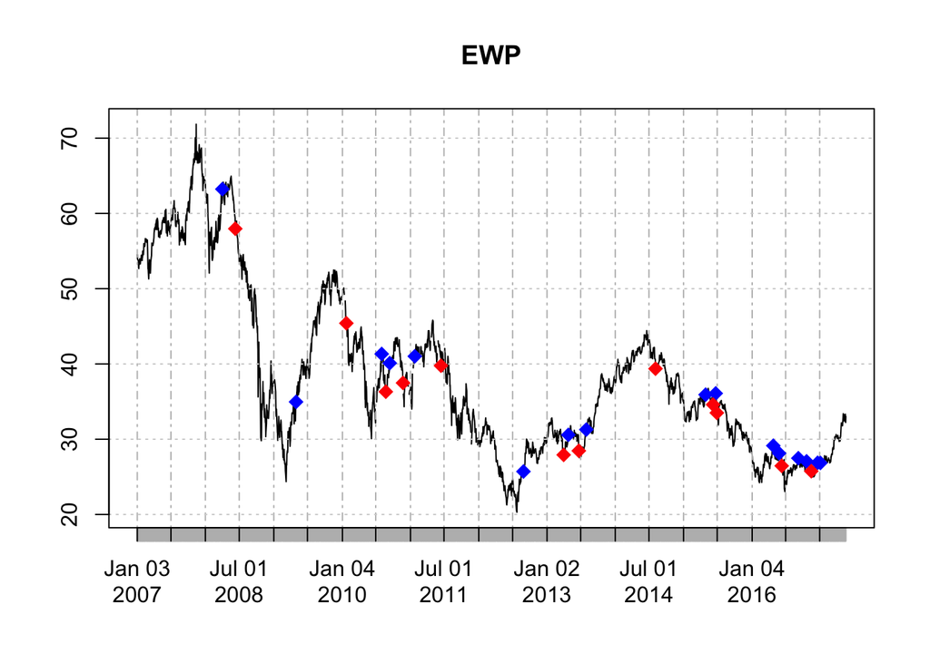

```r
plot(EWP)
points(Long_Trades, col='blue', cex=1.5, pch=18)
points(Short_Trades, col='red', cex=1.5, pch=18)
```

But this is the type of exploration needed to find a system that works for you, for your personality and comfort.